# SOK-2303 - Den nordiske modellen

F1.1 – Introduksjon til den nordiske modellen - NOU 2011:7, kap. 3.1–3.3

Mikko Moilanen

## Esping-Andersens velferdsstatsregimer

1. Stat–marked–familie-dimensjonen
   - arbeidsdelingen mellom de tre hovedtilbyderne av velferd
2. Stratifiseringsdimensjonen
   - i hvilken grad velferdsstatene forsterker eller begrenser de ulikhetene som nødvendigvis ville oppstå i markedet
3. «Dekommodifisering»-dimensjonen
   - i hvilken grad arbeiderne er avhengige av markedet

|  | Liberal | Sosialdemokratisk | Konservativ |
| --- | --- | --- | --- |
| Rollen til |  |  |  |
| Familien | Marginal | Marginal | Sentral |
| Markedet | Sentral | Marginal | Marginal |
| Staten | Marginal | Sentral | Subsidiær |
| Velferdsstaten: |  |  |  |
| Dominerende form for solidaritet | Individuell | Universell | Slektskap Korporatisme Etatisme |
| Dominerende arena for solidaritet | Markedet | Staten | Familien |
| Grad av dekommodifisering | Minimal | Maksimal | Høy (for forsørgeren) |
| Typiske eksempler | USA | Norge | Tyskland, Italia |

### Velferdsstatsmodeller

- Den liberale
  - sosiale ytelser gis **bare til de aller fattigste** etter streng behovsprøving
- Den konservative
  - viderefører status og hierarki skapt i arbeidslivet
    - sosiale ytelser er typisk basert på en forsikringsmodell, slik at **utbetalinger avhenger av hvor stor «premie» som er betalt inn**
- Den sosialdemokratiske
  - større inngrep i markedet
  - **universelle** ytelser som **omfatter hele befolkningen**
    - uavhengig av tidligere opptjening
    - begrenset innslag av økonomisk behovsprøving
- de nordiske lands velferdsstater skiller seg systematisk fra andre land i Europa og OECD

## Den norske velferdsmodellen

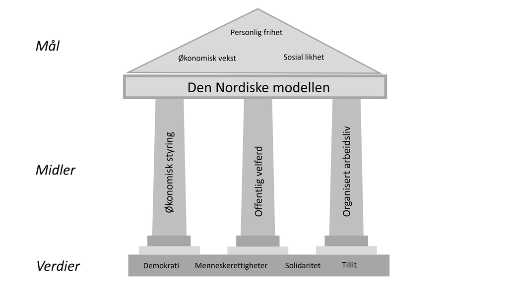

- Norge har klart å kombinere **økonomisk vekst** med stor grad av personlig frihet, **høy yrkesdeltakelse**, **jevn inntektsfordeling**, **høy levestandard** og stor grad av **sosial likhet**
- hovedtrekk ved den norske velferdsmodellen:
  - staten bidrar til **høy yrkesdeltakelse**:
    - vektlegging av gratis offentlig utdanning
    - en omfattende familiepolitikk
    - en aktiv arbeidsmarkedspolitikk
  - et **organisert arbeidsliv** (**trepartssamarbeid** med sterke arbeidsgiver- og arbeidstakerorganisasjoner)
    - sentraliserte og koordinerte lønnsforhandlinger
    - bidrar til små lønnsforskjeller, forutsigbarhet og høy sysselsetting
  - et **skattefinansiert offentlig velferdstilbud** som benyttes av de fleste
    - helse- og omsorgstjenester
    - utdanningstilbud
  - et **godt utbygd og universelt inntektssikring**
    - sjenerøse overføringer ved arbeidsledighet, sykdom, uførhet og alderdom
- modellen har høye velferdspolitiske ambisjoner
  - et sentralt mål: høy yrkesdeltakelse for alle grupper
    - økonomiske hensyn
    - arbeidslivet er en viktig arena for sosial inkludering
  - de statlige inntektssikrings- og velferdsordningene bør legge til rette for at **personer som ikke kan delta i arbeidsmarkedet sikres en levestandard** på et visst nivå
- en svært jevn inntektsfordeling knyttes både til
  - velregulert arbeidsliv og trepartssamarbeid
  - de omfordelende funksjonene til skattesystemet
  - inntektssikringsordningene
  - tjenestesektoren
    - helse og utdanning
- de nordiske velferdsstatene er preget av høy tillit
  - mer tillit både til sine medborgere og til myndighetene
  - tillit er et gode i markedet, og kan være et konkurransefortrinn:
    - bidrar til å redusere kostnadene ved økonomiske transaksjoner

## En bitteliten tillitsundersøkelse

[figure not shown]

## Live oppdatering av resultater

[interactive chart not shown]

## Finansiering av velferdsmodellen

### Kollektiv finansiering av individuelle rettigheter

- et bærende prinsipp for den norske modellen er kollektiv finansiering av **individuelle** rettigheter
  - retten til å benytte seg av tjenestetilbudet eller til å få utbetalt ytelser
    - knyttet til hver enkelt person
    - ikke betinget av hvor mye vedkommende tidligere har bidratt til finansieringen i form av skatt
- på individnivå: ingen krav om at innbetalingene skal tilsvare de samlede utbetalingene
- på makronivå: de samlede inntektene **må være være høye nok** til å dekke de samlede kostnadene

#### Generasjonskontrakten

- for at velferdsmodellen skal være bærekraftig, kreves det at de samlede nettobidragene er tilstrekkelig store til å dekke de samlede nettooverføringene over tid
  - det faktiske finansieringsbehovet vil bl.a. avhenge av befolkningens alderssammensetning

[figure not shown]

Omfordeling over livsløpet. Netto overføringer fra offentlig forvaltning etter alder.1 1 000 kroner. 2024-priser. Kilde: Statistisk sentralbyrå og Finansdepartementet

- det er lite behov for å spare privat til foreldrenes eldreomsorg eller barnas universitetsutdanning
  - ivaretatt gjennom kollektive ordninger den enkelte har et begrenset behov også for å spare privat for å kunne møte risikoen
    - for å bli arbeidsledig
    - for å ikke kunne arbeide fordi man er syk, ufør eller gammel
    - for å få barn
- Velferdsstaten kan forstås som en kollektiv forsikringsordning
  - de ovennevnte risikoene kan vanskelig dekkes i det private forsikringsmarkedet
    - private tilbydere vil ikke kunne stole på at kundene ga dem alle relevante opplysninger om sin egen arbeids- eller helsesituasjon (asymmetrisk informasjon)
    - en fare for at personer endrer atferd, for eksempel blir mer skjødesløse med sin egen helse, når de visste at de var forsikret
    - private forsikringsselskaper er derfor svært restriktive med å selge denne typen forsikringer
      - selv om befolkningen etterspør disse forsikringene

#### Høy yrkesdeltakelse som forutsetning for modellens bærekraft

- høy yrkesdeltakelse er en forutsetning for at modellen skal fungere og være **økonomisk bærekraftig**
  - behov for høye skatteinntekter for å finansiere det omfattende velferdstilbudet
    - jo flere som betaler skatt ==> de samlede skatteinntektene vil være høyere ==> mer bærekraftig velferdsmodell
  - hver stønadsmottaker er kostnadskrevende å finansiere, fordi ytelsene er høye
- det relativt høye skatte- og ytelsesnivået innebærer at én person mindre i arbeid
  - gir inntektssvikt gjennom tapt skatteinngang
  - utgiftsvekst gjennom økte stønadsutbetalinger

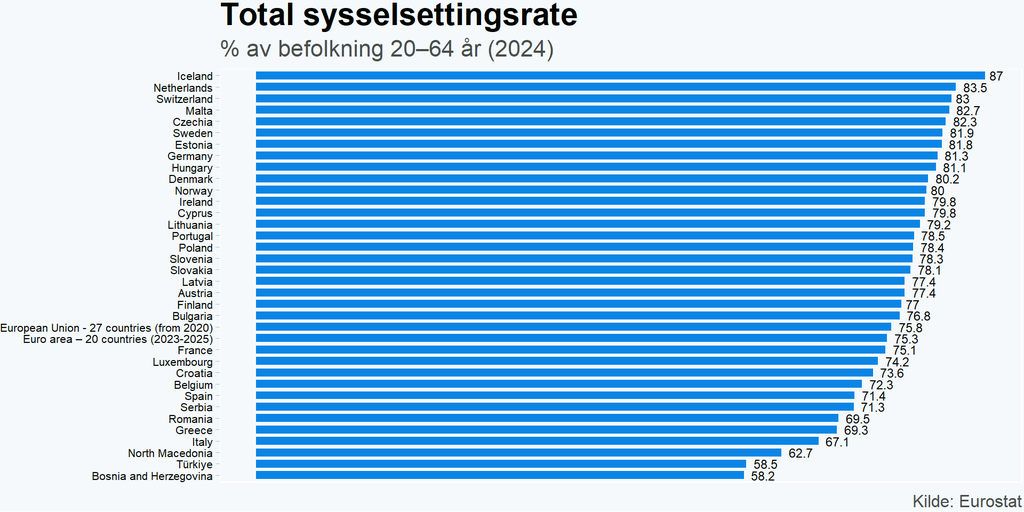

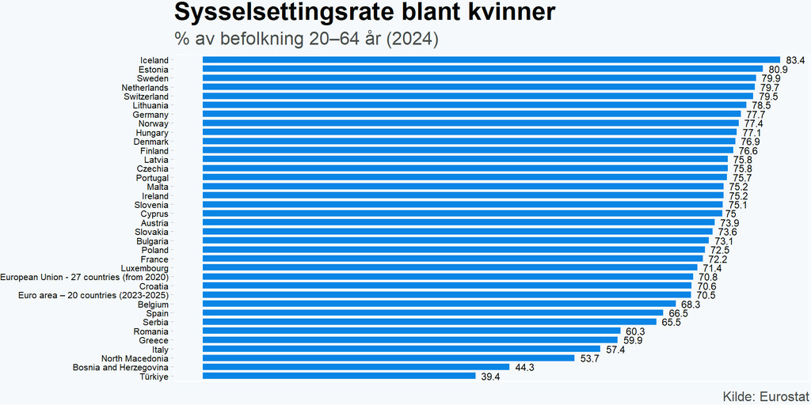

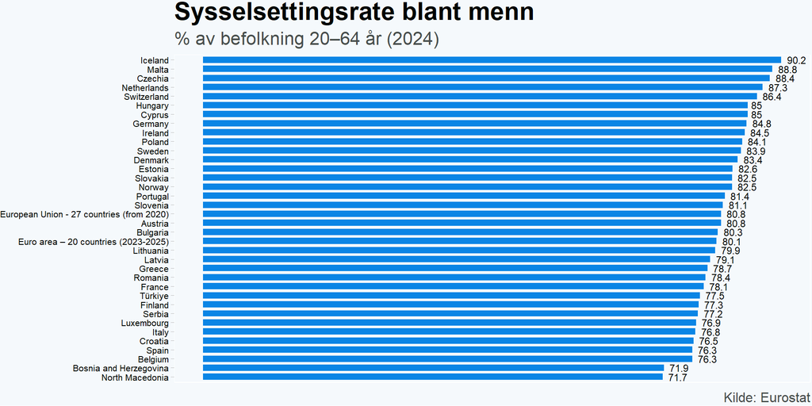

## Den norske arbeidslivsmodellen

### Et organisert arbeidsliv

- kjennetegnet av nært samarbeid mellom myndighetene og arbeidsgiver- og arbeidstakerorganisasjonene
  - samarbeidet er ment til å bidra til
    - å skape en felles forståelse av hovedtrekkene i den økonomiske politikken
    - å legge til rette for god utnyttelse av arbeidskraftsressursene

## Organisasjonsgrad

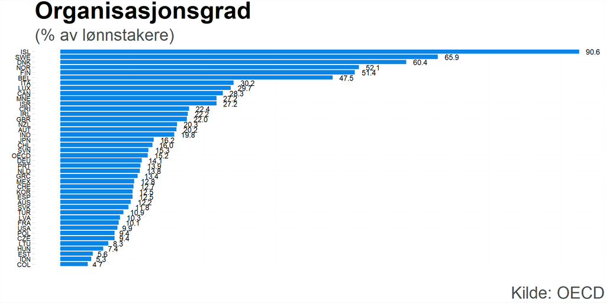

## Organisasjonsgraden i Norge

### Koordinert lønnsdannelse og begrenset lønnsspredning

[figure not shown]

- lønnsdannelsen: stor grad av koordinering mellom arbeidstaker- og arbeidsgiverorganisasjoner
  - partene i arbeidslivet har ansvar for gjennomføringen av lønnsoppgjørene
- modellen tar utgangspunkt i at den samlede lønnsveksten **må tilpasses den veksten konkurranseutsatt sektor over tid kan leve med**
  - **frontfagene** (sektorene som har størst innslag av konkurranseutsatt virksomhet) framforhandler sine avtaler først
    - legger føringer for forhandlingene om øvrige tariffavtaler
- den sentraliserte lønnsdannelsesmodellen har ført til **sammenpresset lønnsstruktur**
  - virker inn fra begge ender av lønnsskalaen
    - **de laveste lønningene øker**
    - **de høyeste lønningene blir redusert**
  - oppnår et relativt **høyt lønnsgulv** og et relativt **lavt lønnstak**
    - et høyt lønnsgulv: stiller krav til at arbeidstakernes utdanning og kvalifikasjoner skal være på et visst nivå
      - høye krav til produktivitet
      - høye krav til kvalifikasjoner blant arbeidstakerne
- en sammenpresset lønnsstruktur innbærer da at
  - de minst produktive bedriftene «presses ut»
    - har ikke har råd til å betale selv de laveste lønningene
  - de høyproduktive bedriftene lykkes og slik bidrar til høy økonomisk vekst
  - bedriftene tjener mer på å benytte ny og effektiv teknologi
    - fører til en raskere modernisering
  - lavproduktiv arbeidskraft tvinges i noen grad ut av arbeidsmarkedet
  - lavproduktiv arbeidskraft kan ha vansker å få innpass på arbeidsmarkedet
    - fordi terskelen for deltakelse blir relativt høy når minstelønningene er høye

## Velferdsstaten

### Inntektssikring

- to hovedtrekk ved inntektssikringsordningene
  - **universelle**
    - som hovedregel inkluderer alle som er bosatt i Norge (bostedsbaserte rettigheter)
  - **individuelle**
    - den enkelte har rettigheter i kraft av seg selv og sin egen situasjon
  - **Siden 1967 har den norske velferdsmodellen kombinert Beveridges og Bismarcks prinsipper**
  - Beveridge-inspirerte ytelser (bostedsbaserte)
    - de flate, universelle ytelsene
      - garanterte minsteytelser til alders- og uførepensjonister
      - de fleste familieytelsene
  - Bismarck-inspirerte ytelser
    - de inntektsbaserte elementene i alders-, uføre- og etterlattepensjoner
    - inntektsavhengige dagpenger, sykepenger og fødselspenger
      - den voksende middelklassen føler at velferdsstatens ytelser er for dem
        - vil ikke ha samme ønske om å kjøpe private tilleggspensjoner som de kanskje ville hatt i en rendyrket modell med universelle ytelser
        - bidrar til å sikre oppslutningen om velferdsordningene
- skattesystemet brukes aktivt i omfordelingspolitikken
  - skatte- og avgiftsinntektene danner grunnlaget for finansiering
  - bidrar til direkte omfordeling, gjennom progressiv inntektsbeskatning og beskatning på bl.a. formue og arv

## Rettigheter og plikter: aktiv arbeidsmarkedspolitkk og sosial investering

### Aktiv arbeidsmarkedspolitkk

- **de relativt høye minstesatsene i velferdssystemet kan være et disinsentiv til arbeid**
- yrkesaktiviteten er likevel høy - delvis sammenheng med at mange ytelsene stiller eksplisitte krav:
  - kreves en viss opptjening før man kan få ut en stønad som er tilstrekkelig høy til å leve et vanlig liv
    - sykepenger og dagpenger utbetales ikke til personer uten tilstrekkelig opptjening
  - krav om yrkesrettet aktivitet for at man skal kunne fortsette å motta ytelser
    - dagpenger: krav om at man må være aktiv arbeidssøker
    - arbeidsavklaringspenger: en jevnlig vurdering av restarbeidsevnen
  - de fleste av stønadene er tidsbegrensede

### Sosial investering

#### Utdanning

- **mål: alle skal ha lik tilgang til grunnutdanning av høy kvalitet**
- ingen siling av elevene i grunnutdanningen
- videregående og høyere utdanning er i all hovedsak gratis
  - studenter har tilgang til stipender og subsidierte lån
- hensikten er å sikre tilgang til utdanning for flest mulig
  - et ledd i den enkeltes velferd
  - for å sikre at samfunnets menneskelige ressurser blir best mulig utnyttet
    - gjennom å legge et godt grunnlag hos alle barn kan oppnå en framtidig arbeidsstokk som både har evne og vilje til å lære raskt

## Kvinners sysselsetting og fertilitet

[interactive chart not shown]

### Barnehager

- barnehager har økt yrkesdeltakelsen
  - frigjør foreldrenes arbeidskraft
    - begge foreldrene kan være i arbeid samtidig
  - en ambisjon at barnehagene skal øke barn og unges læringspotensiale
    - viktig for barn som kommer fra problembelastede familier, eller familier der foreldrene har spesielle problemer på arbeidsmarkedet

[interactive chart not shown]

#### En stor offentlig tjenestesektor

- store variasjoner mellom land i hvordan velferdstjenestene er organisert og finansiert
- det offentlige tjenestetilbudet i Norge er universelt
  - tjenestene er tilgjengelige for alle innbyggerne uten hensyn til kjønn, inntekt/betalingsevne eller bosted
- tjenestene er også stort sett skattefinansierte, med begrensede egenandeler

#### Helsevesenet

- mål: lik tilgang til tjenester uavhengig av bosted, sosial klasse eller inntekt
- helsetjenestene er offentlig eide, og stiller små krav til egenbetaling
- det offentlige både tilbyr tjenestene og betaler for dem
  - ulempen: rasjonering av tjenester må skje gjennom køer
- stor oppslutning om at omsorg for gamle og syke er et offentlig ansvar
  - markedet, frivillige organisasjoner og familien har en mindre rolle

## Økonomiske insentiver og inntektssikring

- høy yrkesdeltakelse er en forutsetning for den norske velferdsmodellens bærekraft
- alle skal sikres en anstendig inntekt, slik at man unngår at det utvikler seg en gruppe arbeidstakere med lave inntekter («working poor»)

### Etterspørsel etter arbeidskraft: økonomiske insentiver for arbeidsgiver

- den norske sammenpressete lønnsstrukturen har relativt høyt lønnsgulv og relativt lavt lønnstak - det stilles relativt høye krav til produktivitet for alle arbeidstakere
- utformingen av inntektssikringssystemet kan bidra til å svekke de økonomiske insentivene til å holde på lavproduktiv arbeidskraft
  - når virksomheten er i økonomiske vanskeligheter kan det være fristende å overføre ordinære lønnskostnader til statlige budsjetter

### Arbeidstilbud: økonomiske insentiver for arbeidstaker

- de fleste inntektssikringsordningene for **friske mennesker i arbeidsfør alder** er tidsbegrensede, og mange av dem innebærer aktivitetskrav
- den enkelte stønadsmottaker kan ikke velge fritt om han eller hun ønsker å delta i arbeidslivet
  - stønadsmottakere har visse muligheter til selv å påvirke hvor fort de kommer i arbeid
    - blant annet gjennom mer eller mindre aktiv jobbsøking
      - helsetilstand
      - muligheten til å velge arbeidstype
      - preferansen for arbeid eller fritid
- **Arbeidslinja**: ordningene er ment til være utformet på en slik måte at de motiverer til deltakelse i arbeidslivet framfor mottak av ulike stønader